# Meet the {GGally} package

Allison Horst

2020-07-07

The delightful [{GGally}](https://www.rdocumentation.org/packages/GGally/versions/1.5.0) package, by [Barret Schloerke](http://schloerke.com/) and other contributors, makes it easier to explore relationships and patterns for multivariate data. In the following examples, we show several {GGally} functions to visualize your data using the [{palmerpenguins}](https://allisonhorst.github.io/palmerpenguins/) package (install from GitHub for now – hopefully on CRAN soon).

```r
library(tidyverse)
library(palmerpenguins)
library(skimr)
library(GGally)
```

## 1. Check out the penguins data!

First, some of our go-to ways to explore data, using the **penguins** object from {palmerpenguins}. The data were originally collected and published by [Dr. Kristen Gorman](https://www.uaf.edu/cfos/people/faculty/detail/kristen-gorman.php) and the [Palmer Station LTER](https://pal.lternet.edu/). Structural size measurements for nesting adults of three penguin species (Adélie, Chinstrap and Gentoo) were recorded on islands in Palmer Archipelago, Antarctica, from 2007 - 2009.

```r
# Bring it up in a new tab
# View(penguins)

# Summarize it
summary(penguins)
```

```
##       species          island    bill_length_mm  bill_depth_mm
##  Adelie   :152   Biscoe   :168   Min.   :32.10   Min.   :13.10
##  Chinstrap: 68   Dream    :124   1st Qu.:39.23   1st Qu.:15.60
##  Gentoo   :124   Torgersen: 52   Median :44.45   Median :17.30
##                                  Mean   :43.92   Mean   :17.15
##                                  3rd Qu.:48.50   3rd Qu.:18.70
##                                  Max.   :59.60   Max.   :21.50
##                                  NA's   :2       NA's   :2
##  flipper_length_mm  body_mass_g       sex           year
##  Min.   :172.0     Min.   :2700   female:165   Min.   :2007
##  1st Qu.:190.0     1st Qu.:3550   male  :168   1st Qu.:2007
##  Median :197.0     Median :4050   NA's  : 11   Median :2008
##  Mean   :200.9     Mean   :4202                Mean   :2008
##  3rd Qu.:213.0     3rd Qu.:4750                3rd Qu.:2009
##  Max.   :231.0     Max.   :6300                Max.   :2009
##  NA's   :2         NA's   :2
```

```r
# Glimpse it
tibble::glimpse(penguins)
```

```
## Rows: 344
## Columns: 8
## $ species           <fct> Adelie, Adelie, Adelie, Adelie, Adelie, Adelie, Ade…
## $ island            <fct> Torgersen, Torgersen, Torgersen, Torgersen, Torgers…
## $ bill_length_mm    <dbl> 39.1, 39.5, 40.3, NA, 36.7, 39.3, 38.9, 39.2, 34.1,…
## $ bill_depth_mm     <dbl> 18.7, 17.4, 18.0, NA, 19.3, 20.6, 17.8, 19.6, 18.1,…
## $ flipper_length_mm <int> 181, 186, 195, NA, 193, 190, 181, 195, 193, 190, 18…
## $ body_mass_g       <int> 3750, 3800, 3250, NA, 3450, 3650, 3625, 4675, 3475,…
## $ sex               <fct> male, female, female, NA, female, male, female, mal…
## $ year              <int> 2007, 2007, 2007, 2007, 2007, 2007, 2007, 2007, 200…
```

```r
# Skim it
skimr::skim(penguins)
```

Data summary

| Name | penguins |
| --- | --- |
| Number of rows | 344 |
| Number of columns | 8 |
| _______________________ |  |
| Column type frequency: |  |
| factor | 3 |
| numeric | 5 |
| ________________________ |  |
| Group variables | None |

**Variable type: factor**

| skim_variable | n_missing | complete_rate | ordered | n_unique | top_counts |
| --- | --- | --- | --- | --- | --- |
| species | 0 | 1.00 | FALSE | 3 | Ade: 152, Gen: 124, Chi: 68 |
| island | 0 | 1.00 | FALSE | 3 | Bis: 168, Dre: 124, Tor: 52 |
| sex | 11 | 0.97 | FALSE | 2 | mal: 168, fem: 165 |

**Variable type: numeric**

| skim_variable | n_missing | complete_rate | mean | sd | p0 | p25 | p50 | p75 | p100 | hist |
| --- | --- | --- | --- | --- | --- | --- | --- | --- | --- | --- |
| bill_length_mm | 2 | 0.99 | 43.92 | 5.46 | 32.1 | 39.23 | 44.45 | 48.5 | 59.6 | ▃▇▇▆▁ |
| bill_depth_mm | 2 | 0.99 | 17.15 | 1.97 | 13.1 | 15.60 | 17.30 | 18.7 | 21.5 | ▅▅▇▇▂ |
| flipper_length_mm | 2 | 0.99 | 200.92 | 14.06 | 172.0 | 190.00 | 197.00 | 213.0 | 231.0 | ▂▇▃▅▂ |
| body_mass_g | 2 | 0.99 | 4201.75 | 801.95 | 2700.0 | 3550.00 | 4050.00 | 4750.0 | 6300.0 | ▃▇▆▃▂ |
| year | 0 | 1.00 | 2008.03 | 0.82 | 2007.0 | 2007.00 | 2008.00 | 2009.0 | 2009.0 | ▇▁▇▁▇ |

## 2. Visual overview of relationships with {GGally} package

More on {GGally}: https://ggobi.github.io/ggally/

Summary: “GGally extends ggplot2 by adding several functions to reduce the complexity of combining geoms with transformed data. Some of these functions include a pairwise plot matrix, a scatterplot plot matrix, a parallel coordinates plot, a survival plot, and several functions to plot networks.”

### A. `ggpairs()`: a pair plot!

Out of the box:

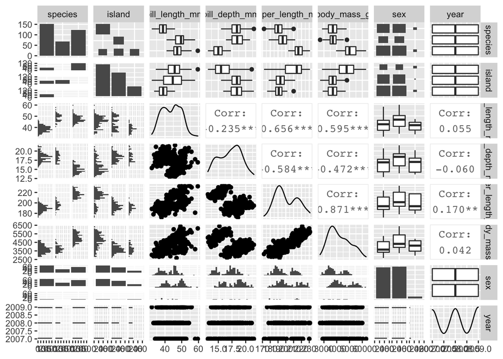

```r
ggpairs(penguins)
```

That should make you go “What.” It’s cool but a bit much. We can specify what we want in our pairs plot, and map color onto a variable to separate groups.

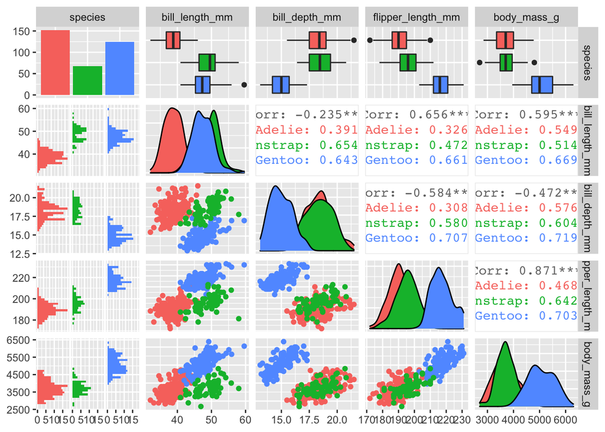

```r
penguins %>%
  select(species, bill_length_mm:body_mass_g) %>%
  ggpairs(aes(color = species))
```

### B. `ggbivariate()`: plot outcome variable with several explanatory variables

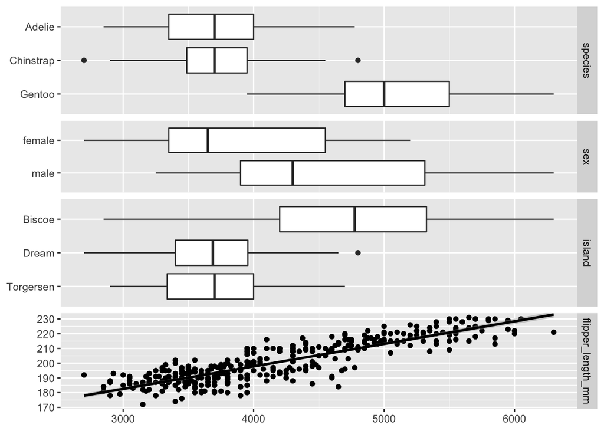

```r
penguins %>%
  ggbivariate(outcome = "body_mass_g",
              explanatory = c("species","sex", "island","flipper_length_mm"))
```

An example with custom formatting:

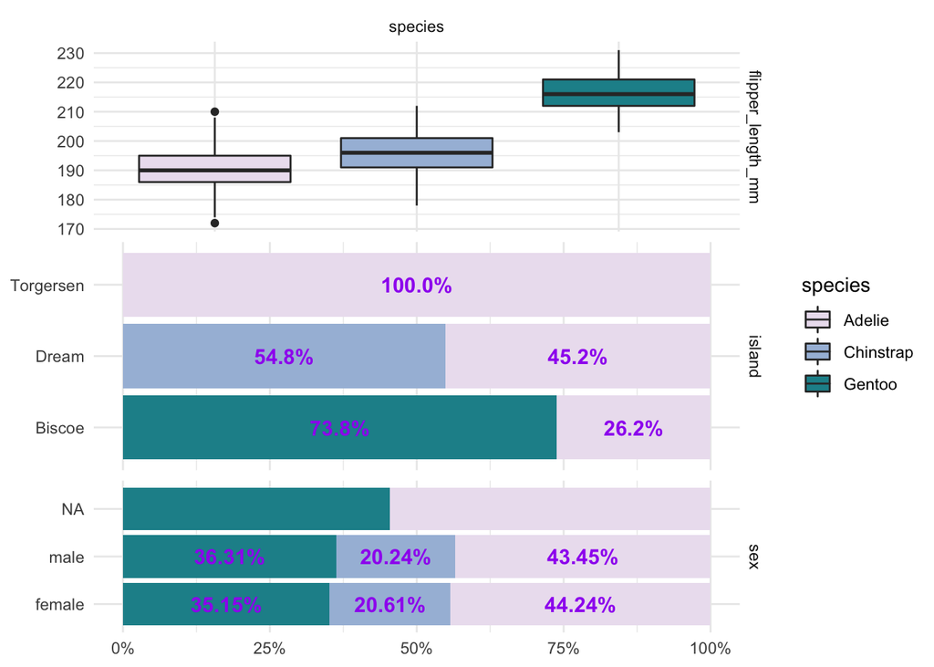

```r
penguins %>%
  ggbivariate(outcome = "species",
              explanatory = c("flipper_length_mm", "island", "sex"),
              rowbar_args = list(
    colour = "purple",
    size = 4,
    fontface = "bold",
    label_format = scales::label_percent(accurary = 1)
  )) +
  scale_fill_brewer(palette = 10) +
  theme_minimal()
```

### C. `ggnostic()`: Model diagostics

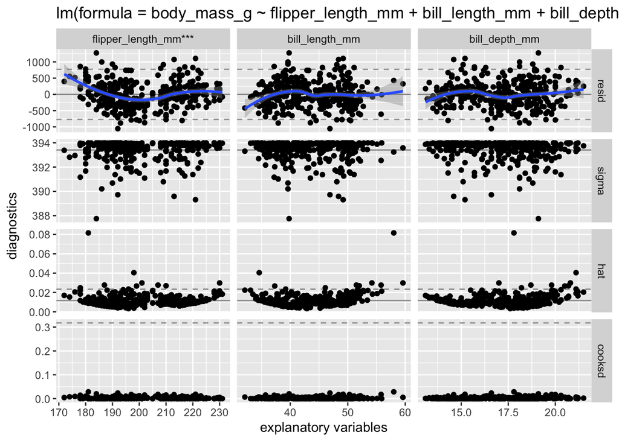

```r
# Make a model:
penguin_lm <- lm(body_mass_g ~ flipper_length_mm + bill_length_mm + bill_depth_mm, data = penguins)

# Look at the diagnostics!
ggnostic(penguin_lm)
```

### D. `ggtable()`: Nicely formatted counts tables

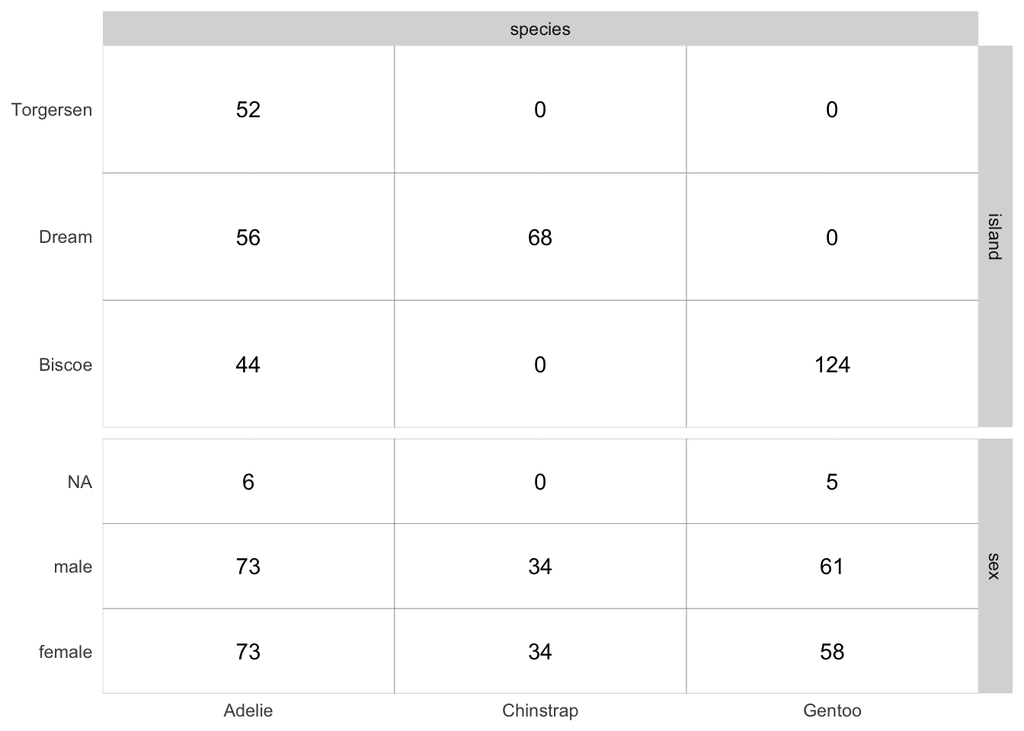

```r
# Counts, for each species, tallied by island & sex
penguins %>%
  ggtable("species", c("island","sex"))
```

And much more! Check out {GGally} for more tools to explore and visualize your multivariate data!